# Fitted-Model-Based Annotations

‘ggpmisc’ 1.0.0

Pedro J. Aphalo

2026-07-05

# Purpose

Package ‘ggpmisc’ makes it easier to add to plots created using ‘ggplot2’ annotations based on fitted models and other statistics. It does this by wrapping existing model fit and other functions. The same annotations can be produced by calling the model fit functions, extracting the desired estimates and adding them to plots. There are two advantages in wrapping these functions in an extension to package ‘ggplot2’: 1) we ensure the coupling of graphical elements and the annotations by building all elements of the plot using the same data and a consistent grammar and 2) we make it easier to annotate plots to the casual users of R familiar with the grammar of graphics.

*To avoid confusion it is good to make clear what may seem obvious to some: if no plot is needed, then there is no reason to use this package. The values shown as annotations are not computed within ‘ggpmisc’ but instead by the usual model-fit and statistical functions from R and R packages. The same is true for model predictions, residuals, etc., that some of the functions in ‘ggpmisc’ display as lines, segments, or other graphical elements.*

It is also important to remember that in most cases data analysis proper should take place before annotated plots for publication are produced. Even though data analysis can benefit from combined numerical and graphical representation of the results, the use I envision for ‘ggpmisc’ is mainly for the production of plots for publication or communication.

Attaching package ‘ggpmisc’ also attaches package ‘ggpp’ as this package was created as a spin-off from ‘ggpmisc’. ‘ggpp’ provides several of the geometries used by default in the statistics described below. Package ‘ggpp’ can be loaded and attached on its own, and has [separate on-line documentation](https://docs.r4photobiology.info/ggpp/).

The [on-line documentation of ‘ggpmisc’](https://docs.r4photobiology.info/ggpp/) includes articles/vignettes not installed with the package. These articles contain use examples covering annotations based on additional model fitting functions, including user-defined ones. These articles also describe the use of `ggpmisc` together with some other R packages including ‘ggrepel’, ‘gganimate’, ‘ggtext’, ‘marquee’ and ‘xdvir’. With the last three packages, automatically generated *Markdown* and $\LaTeX$ formatted equations and other labels can be added to plots.

# Introduction to computed annotations

When continuous variables are mapped to both of *x* and *y* aesthetics, fitted model predictions are often displayed as curves and bands in plots. To facilitate interpretation or further use, fitted-model equations, tests of significance and various indicators of goodness of fit are diplayed as plot annotations. Occasionally an ANOVA table or a summary table as a plot inset can help interpretation. Other annotations computed from data are parametric and non-parametric correlations and their significance and other summaries. Data labels indicate the location of local or global maxima and minima and other features of the data.

When one of variables mapped to *x* or *y* aesthetics is a factor and the other a continuous variable, an ANOVA table as a plot inset can be useful. However, most (too?) frequently the outcomes of pairwise contrasts are indicated using letters or connecting labels. Several additional statistics for simple plot annotations computed from `data` but not dependent of fitting of statistical models are documented in the vignettes and help pages of package ‘ggpp’ even if these statistics are imported and re-exported by ‘ggpmisc’.

‘ggpmisc’ not only implements a good assortment of annotations, it implements them using an open-ended approach that makes it possible to work with many different model-fitting methods. ‘ggpmisc’ expands the range of plots and data visualisation features available within the grammar of graphics. While some R packages like ‘ggpubr’ easy construction of everyday plots, ‘ggpmisc’ aims to make it possible the construction of data visualizations that communicate effectively the outcomes from a broader range of statistical methods.

Computed and model-fit based annotations are implemented in ‘ggpmisc’ as new statistics that do computations on the plot data and pass the results to existing or new geometries. These new statistics are only a convenience in the sense that similar plots can be achieved by fitting models and operating on the fitted model objects to extract estimates and outcomes of tests passing them as data directly to geoms in a plot. This approach requires additional coding by users to assemble character strings to be parsed into R expressions (or encoded using markdown or $\LaTeX$ or $\TeX$). Fitting the models before constructing the plot object can weaken reproducibility as the values in the annotations are not computed at the time the plot is rendered and not guaranteed to use the data being plotted (*When using ‘ggpmisc’ statistics the user remains responsible for the consistency of methods and model formulas used in different plot layers!*).

The statistics defined in ‘ggpmisc’ even if usable with geometries from package ‘ggplot2’, in most cases have as default geometries defined in package ‘ggpp’. These new geometries are better suited for plot annotations than those from ‘ggplot2’, which are designed for data labels.

In user interfaces there is always a compromise between simplicity and flexibility in which the choice of default arguments plays a key role in finding a balance. I have aimed to make everyday use simple without limiting the flexibility inherent to the Grammar of Graphics. However, the assumption is that users desire/need the flexibility inherent in the layered approach of the Grammar of Graphics, and that the layer functions provided will be combined with those from ‘ggplot2’, ‘ggpp’ and other packages extending the Grammar of Graphics as implemented in ‘ggplot2’.

# Statistics

Currently, the core statistics made available by package ‘ggpmisc’ help with reporting parameter- and other estimates from fitted models, both as equations and numbers in annotations and by plotting. Similarly to `ggplot2::stat_smooth()` they call model-fit-functions to fit a model-formula to the plot-layer data and, as all ggplot statistics, return new `data` as a data frame that is in turn passed to a geometry. The statistics are `stat_poly_line()`, `stat_poly_eq()`, `stat_ma_line()`, `stat_ma_eq()`, `stat_quant_line()`, `stat_quant_band()`, `stat_quant_eq()`, `stat_fit_residuals()`, `stat_fit_deviations()`, `stat_fit_glance()`, `stat_fit_augment()`, `stat_fit_tidy()` and `stat_fit_tb()`. Most of these statistics support orientation flipping, both using parameter `orientation` similarly to package ‘ggplot2’ in recent versions or through a model `formula` with `x` as response variable and `y` as explanatory variable. In addition, `stat_correlation()` helps with the reporting of Pearson, Kendall and Spearman correlations. Finally, `stat_distrmix_line()` and `stat_distrmix_eq()` support the fitting of mixtures of probability density distributions.

These statistics support grouping and faceting. In the case of those that return character strings to be mapped to the `label` aesthetic they also return suitable `x` and `y`, or `npcx` and `npcy` values as well as `hjust` and `vjust` values. These default values ensure that the annotations do not spill ouside the edges of the plotting area. The automatic computation of these positions can be adjusted through arguments passed to these statistics and also overridden by user-supplied manual positions.

**Not all possible model formulas can be decoded to produce valid fitted model equations. In most cases, for incompatible model formulas, no equation label is automatically generated, and a warning triggered. Other labels such as $R^2$ are nearly always generated. When not automatically generated, a suitable fitted model equation can be assembled by user code within the aesthetic mapping using the numeric values that are also returned.**

Initially, `stat_poly_eq()` and `stat_poly_line()` supported only `lm()` as model fit function, as time passed by support for additional specific model fit functions was added. Since ‘ggpmisc’ (>= 0.5.0) user-defined functions have been supported as long as the class of the model fit object they return matches one corresponding to one of the supported model fit functions. Since ‘ggpmisc’ (>= 0.6.2) support is expanded to include arbitrary model fit functions for which the necessary fitted model object query methods are available. **In this last case a warning is issued as the extraction of estimates can fail and `NA` values returned for some or all labels. Most importantly, the correctness of the extracted estimates needs to be checked when the warning is issued as in these cases there is no assurance of correctness.**

Table 1 below summarizes the use of the model-fittings statistics and the default geometries. The statistics `stat_fit_glance()` and `stat_fit_tidy()` require in their use more effort as the mapping to aesthetics and conversion of numeric values into character strings must be coded in the layer function call, but on the other hand they support all model fit objects catered by package ‘broom’ itself or any of the packages extending ‘broom’ such as ‘broom.mixed’ (see next section).

**Table 1. Summary of features of the statistics.** Returned values can be accessed in `ggplot2::aes()` with function `ggplot2::after_stat(<variable name>)` where `<variable name>` is the name of one of a variable in the data frame returned by the statistics. Notes: (1) *weight* aesthetic supported; (2) user defined model fit functions including wrappers of supported methods are accepted even if they modify the model *formula* (additional model fitting methods are likely to work, but have not been tested); (3) unlimited quantiles supported; (4) user defined fit functions that return an object of a class derived from `rq` or `rqs` are supported even if they override the statistic’s *formula* and/or *quantiles* argument; (5) two and three quantiles supported; (6) user defined fit functions that return an object of a class derived from `lmodel2` are supported; (7) `method` arguments support colon based notation; (8) model fit functions if method `residuals()` defined for returned value; (9) model fit functions if method `fitted()` is defined for the returned value.

| Statistic | Returned values (*default geometry*) | Methods |
| --- | --- | --- |
| **Model equation** | *parameter estimates* |  |
| `stat_poly_eq()` | equation, *R*<sup>2</sup>, *P*, etc. (`text_npc`) | lm, rlm, lts, gls, ma, sma, etc. (1, 2, 7) |
| `stat_ma_eq()` | equation, *R*<sup>2</sup>, *P*, etc. (`text_npc`) | lmodel2 (6, 7) |
| `stat_quant_eq()` | equation, *P*, etc. (`text_npc`) | rq, rqss (1, 3, 4, 7) |
| `stat_distrmix_eq()` | equation(s) (`text_npc`) | normalmixEM (2, 7) |
| `stat_correlation()` | correlation, *P*-value, CI (`text_npc`) | Pearson (*t*), Kendall (*z*), Spearman (*S*) |
| `stat_fit_glance()` | equation, *R*<sup>2</sup>, *P*, etc. (`text_npc`) | those supported by ‘broom’ |
| **Model line** | *predicted and fitted values* |  |
| `stat_poly_line()` | line + conf. (`smooth`) | lm, rlm, lts, gls, ma, sma, etc. (1, 2, 7) |
| `stat_ma_line()` | line + slope conf. (`smooth`) | lmodel2 (6, 7) |
| `stat_quant_line()` | line + conf. (`smooth`) | rq, rqss (1, 3, 4, 7) |
| `stat_quant_band()` | line + band, 2 or 3 quantiles (`smooth`) | rq, rqss (1, 4, 5, 7) |
| `stat_distrmix_line()` | lines(s) (`line`) | normalmixEM (2, 7) |
| `stat_fit_augment()` | predicted and other values (`smooth`) | those supported by ‘broom’ |
| `stat_fit_fitted()` | fitted values (`point`) | lm, rlm, lts, gls, rq, rqss, etc. (1, 2, 4, 7, 9) |
| `stat_fit_deviations()` | deviations from observations (`segment`) | lm, rlm, lts, gls, rq, rqss, etc. (1, 2, 4, 7, 9) |
| **Model table** | *parameter estimates and significance* |  |
| `stat_fit_tb()` | ANOVA and summary tables (`table_npc`) | those supported by ‘broom’ |
| `stat_fit_tidy()` | fit results, e.g., for equation (`text_npc`) | those supported by ‘broom’ |
| **Contrasts** | *Tukey, Dunnet and arbitrary pairwise* |  |
| `stat_multcomp()` | Multiple comparisons (`label_pairwise` or `text`) | those supported by `glht` (1, 2, 7) |
| **Residuals** | *model fit residuals* |  |
| `stat_fit_residuals()` | residuals (`point`) | lm, rlm, lte, gls, rq, rqss, etc. (1, 2, 4, 7, 8) |

## Model equations and other annotations

Statistics `stat_poly_eq()` , `stat_ma_eq()` , `stat_quant_eq()`, `stat_distrmix_eq()` and `stat_correlation()` return by default ready formatted character strings that can be mapped to the `label` aesthetic individually or concatenated. The convenience function `use_label()` makes this easier by accepting abbreviated/common names for the component labels, and handling both the concatenation and mapping to the `label` aesthetics. For full flexibility in the assembly of concatenated labels `paste()` or `sprintf()` functions can the used within a call to `ggplot2::aes()`. By default the character strings are formatted ready to be parsed as R expressions. Optionally they can be formatted as R Markdown, $\LaTeX$ or plain text as shown in the table below.

These statistics as of ‘ggpmisc’ (>= 0.5.0) allow additional flexibility in the model fit `method` functions: they can be any function with a suitable interface, as long as they return a fitted model object of the expected class, or that inherits from the expected class. When possible, in `stat_poly_eq()`, the model formula is retrieved from the model fit object, and this retrieved model formula overrides, only in the returned value, the one supplied as argument by the user. In practice, this means that `method` can be a function that does model selection. This is specially useful with grouped data and facets, making it possible for model formula to vary from group to group or from panel to panel within a single ggplot object.

The returned values for `output.type` different from `numeric` are shown below in Table 2. The variable mapped by default to the `label` aesthetics is indicated with an asterisk. The returned values for `x` and `y` are for the default computed location of the labels. The returned data frame has one row per group of observations in each panel of the plot.

Function `use_label()` provides an easy way of selecting, possibly combining and mapping the text labels for different parameters from a model fit, supporting the use of both *variable names* such as `"eq.label"` and `"rr.label"` and abbreviations or symbols used in statistics such as `"eq"` and `"R2"`.

**Table 2.** Formatted character values returned by `stat_poly_eq()`, `stat_ma_eq()`, `stat_quant_eq()`, `stat_distrmix_eq()`, `stat_correlation()` and `stat_multcomp()` for `output.type` different from `numeric`.** Column *variable* gives the variable name in the returned `data` and should be used together with `after_stat()` when mapping to aesthetics using `aes()`. When using function `use_label()`, the short abbreviation shown in column *Key* can be used as a synonym, although full names are also supported. Column *Mode* describes the type of the values in each variable. **Notes:** (1) Inclusion of the variable in the returned `data` depends on the argument passed to parameter `method`. (2) Depending on the geometry in use either `x` and `y` or `npcx` and `npcy` are set to `NA`. (3) Depends on `label.type`. * Indicates the default mapping to `label` aesthetic.

| Variable | Key | Mode | `poly_eq` | `ma_eq` | `quant_eq` | `correlation` | `multcomp` | `distrmix_eq` |
| --- | --- | --- | --- | --- | --- | --- | --- | --- |
| eq.label | eq | character | y | y | y* | n | n | y |
| rr.label | R2 | character | y* | y* | n | y(1) | n | n |
| rr.confint.label | R2.CI | character | y | n | n | n | n | n |
| adj.rr.label | adj.R2 | character | y | n | n | n | n | n |
| cor.label | cor | character | n | n | n | y(1) | n | n |
| rho.label | rho | character | n | n | y | y(1) | n | n |
| tau.label | tau | character | n | n | n | y(1) | n | n |
| r.label | R | character | n | n | n | y* | n | n |
| cor.confint.label | cor.CI | character | n | n | n | y(1) | n | n |
| rho.confint.label | rho.CI | character | n | n | y | y(1) | n | n |
| tau.confint.label | tau.CI | character | n | n | n | y(1) | n | n |
| r.confint.label | R.CI | character | n | n | n | y | n | n |
| f.value.label | F | character | y | n | n | n | n | n |
| t.value.label | t | character | n | n | n | y(1) | y | n |
| z.value.label | z | character | n | n | n | y(1) | n | n |
| S.value.label | S | character | n | n | n | y(1) | n | n |
| p.value.label | P | character | y | y | n | y | y | n |
| delta.label | delta | character | n | n | n | n | y (3) | n |
| letters.label | delta | character | n | n | n | n | y (3) | n |
| AIC.label | AIC | character | y | n | y | n | n | n |
| BIC.label | BIC | character | y | n | n | n | n | n |
| knots.label |  | character | y(4) | n | n | n | n | n |
| n.label | n | character | y | y | y | y | y | y |
| grp.label | grp | character | y | y | y | y | y | n |
| method.label | method | character | y | y | y | y | n | y |

In some cases it is desirable to alter the formatting based on the outcome from a model fit, i.e., based on the value of parameter estimates. In other cases, some ready formatted labels can be in the desired format, while other need to be manually formatted. To catter for these situations, multiple parameter estimates and test outcomes are also returned as raw numeric or raw character values. The values returned for all `output.type` values, including `"numeric"` are shown below in Table 3.

**Table 3.** Raw values returned by `stat_poly_eq()` , `stat_ma_eq()` , `stat_quant_eq()`, `stat_distrmix_eq()`, `stat_correlation()` and `stat_multcomp()` for all `output.type` values.

| Variable | Key | Mode | `poly_eq` | `ma_eq` | `quant_eq` | `correlation` | `multcomp` | `distrmix_eq` |
| --- | --- | --- | --- | --- | --- | --- | --- | --- |
| coefs |  | numeric | y | y | n | n | n | n |
| r.squared |  | numeric | y | y | n | n | n | n |
| adj.r.squared |  | numeric | y | n | n | n | n | n |
| rho |  | numeric | n | n | y | y(1) | n | n |
| tau |  | numeric | n | n | n | y(1) | n | n |
| cor |  | numeric | n | n | n | y(1) | n | n |
| f.value |  | numeric | y | y | n | y | y | n |
| f.df1 |  | numeric | y | y | n | y | y | n |
| f.df2 |  | numeric | y | y | n | y | y | n |
| f.value |  | numeric | y | y | n | y | y | n |
| t.value |  | numeric | n | n | n | n | n | y |
| t.df |  | numeric | n | n | n | n | n | y |
| z.value |  | numeric | n | n | n | y(1) | n | n |
| S.value |  | numeric | n | n | n | y(1) | n | n |
| p.value |  | numeric | y | y | n | y | n | n |
| lambda |  | numeric | n | n | n | n | n | y |
| mu |  | numeric | n | n | n | n | n | y |
| sigma |  | numeric | n | n | n | n | n | y |
| lambda.se |  | numeric | n | n | n | n | n | y |
| mu.se |  | numeric | n | n | n | n | n | y |
| sigma.se |  | numeric | n | n | n | n | n | y |
| knots |  | numeric | y(4) | n | n | n | n | n |
| knots.se |  | numeric | y(4) | n | n | n | n | n |
| component |  | factor | n | n | n | n | n | y |
| n |  | numeric | y | y | y | y | y | y |
| rq.method |  | character | n | n | y | n | n | n |
| method |  | character | y | y | y | y | n | y |
| test |  | character | n | n | n | y | n | n |
| quantile |  | numeric | n | n | y | n | n | n |
| quantile.f |  | factor | n | n | y | n | n | n |
| fm.method |  | character | y | y | y | y | y | y |
| fm.class |  | character | y | y | y | y | y | n |
| fm.formula.chr |  | character | y | y | y | y | y | n |
| converged |  | logical | n | n | n | n | n | y |
| .size |  | numeric | n | n | n | n | n | y |
| mc.adjusted |  | character | n | n | n | n | y | n |
| mc.contrast |  | character | n | n | n | n | y | n |
| xmin/ymin |  | numeric | n | n | n | n | y (3) | n |
| xmax/ymax |  | numeric | n | n | n | n | y (3) | n |
| x(2) |  | numeric | y | y | y | y | y | y |
| y(2) |  | numeric | y | y | y | y | y | y |
| npcx(2) |  | numeric | y | y | y | y | n | y |
| npcy(2) |  | numeric | y | y | y | y | n | y |

Even though the number of significant digits and some other formatting can be adjusted by passing arguments when calling the statistics function, in some cases it maybe necessary for the user to do the conversion of numeric values into character strings. One case is when the fitted model is not a polynomial, as in this case `eq.label` needs to be assembled and formatted in user code within a call to `aes()`. For these special cases, the statistics can return additional values as `numeric`. The values returned only for `output.type` equal to `numeric` are shown below in Table 4.

**Table 4.** Raw values returned by `stat_poly_eq()` , `stat_ma_eq()` , `stat_quant_eq()`, `stat_distrmix_eq()`, and `stat_correlation()` only for `output.type` equal to `numeric`.

| Variable | Mode | `poly_eq` | `ma_eq` | `quant_eq` | `correlation` | `distrmix_eq` |
| --- | --- | --- | --- | --- | --- | --- |
| coef.ls | list | y | y | y | n | n |
| b_0.constant | numeric | y | y | y | n | n |
| b_0 | numeric | y | y | y | n | n |
| b_1 | numeric | y | y | y | n | n |
| b_2…b_n | numeric | y | y | y | n | n |

In the cases of the statistics based on the methods from package ‘broom’ and its extensions, the returned value depends on that of the method specialization that is automatically dispatched based on the class of the model fit object returned by the `method` function (Table 5). The expectation is that these statistics will be used only in cases when those described above cannot be used. Implementation based on generic methods from package ‘broom’ and its extensions provides support for very many different model fit procedures, but at the same time requires that the user consults the documentation of these broom methods and that the user builds the character strings for labels in his own code. The simplest way of discovering what variables are returned is to use `gginnards::geom_debug_group()` to explore the returned data frame. Examples are included in the help to some of the statistics and in a later section of this User Guide.

**Table 5.** Values always returned by `stat_fit_tb()`, `stat_fit_tidy()`, `stat_fit_glance()` and `stat_fit_augment()`. As these statistics call generic methods and return their output, only a few variables are guaranteed to be consistently present in the returned `data`. **Note:** (1) Depending on the geometry in use either `x` and `y` or `npcx` and `npcy` are set to `NA`.

| Variable | Mode | `fit_tb` | `fit_tidy` | `fit_glance` | `fit_augment` |
| --- | --- | --- | --- | --- | --- |
| *broom method* |  | `tidy()` | `tidy()` | `glance()` | `augment()` |
| x(1) | numeric | y | y | y | y |
| y(1) | numeric | y | y | y | y |
| npcx(1) | numeric | y | y | y | n |
| npcy(1) | numeric | y | y | y | n |
| fm.tb | data.frame | y | n | n | n |
| fm.tb.type | character | y | n | n | n |
| fm.method | character | y | y | y | y |
| fm.class | character | y | y | y | y |
| fm.formula.chr | character | y | y | y | y |

Statistics `stat_poly_line()`, `stat_ma_line()`, `stat_quant_line()`, `stat_quant_band()` and `stat_distrmix_line()` return objects similar to those returned by `ggplot2:stat_smooth()`.

## Fitted lines, confidence bands and residuals

Statistics `stat_fit_residuals()` and `stat_fit_deviations()` can be used to plot the residuals of model fits on their own and to highlight them in a plot of the fitted model curve, respectively.

## ANOVA and summary tables

Statistic `stat_fit_tb()` can be used to add ANOVA or summary tables as plots insets. While the statistics described in the two previous subsections are useful when fitting curves when both `x` and `y` are mapped to continuous `numeric` variables, `stat_fit_tb()` is also suitable for cases when `x` or `y` is a `factor` .

Which columns from the objects returned by R’s `anova()` and `summary()` methods as well as which terms from the model `formula` are included in the inset table can be selected by the user. Column headers and term names can also be replaced by R expressions. This statistics uses `ggpp::geom_table()` , a geometry that supports table formatting styles.

## Annotations based on package ‘broom’

Package ‘broom’ provides a *translation layer* between various model fit functions and a consistent naming and organization for the returned values. This made it possible to design statistics `stat_fit_glance()` and `stat_fit_augment()` that provide similar capabilities as those described above and that work with any of the many model fit functions supported by package ‘broom’ and its extensions. This means that the returned data are in columns with generic names. Consequently, when using `stat_fit_glance()` text labels need to be created in user code and then mapped to the `label` aesthetic and when using `stat_fit_augment()` with complex fitted models know the details of the model fitting functions used.

## Other data features

Statistics `stat_peaks()` and `stat_valleys()` can be used to locate and annotate global and local maxima and minima in the variable mapped to the `y` (or `x` ) aesthetic. Date time variables mapped to the `x` or `y` aesthetics are supported.

# Scales

When plotting *omics* data we usually want to highlight observations based on the outcome of tests of significance for each one of 100’s or 1000’s genes or metabolites. We define some scales, as wrappers on continuous `x` and `y` scales from package `ggplot2` that are suitable for 1) differences in abundance expressed as fold changes, 2) *P*-value and 3) FDR.

Scales `scale_x_logFC()` and `scale_y_logFC()` are suitable for plotting of log fold change data. Scales `scale_x_Pvalue()`, `scale_y_Pvalue()`, `scale_x_FDR()` and `scale_y_FDR()` are suitable for plotting *p*-values and adjusted *p*-values or false discovery rate (FDR). Default arguments are suitable for volcano and quadrant plots as used for transcriptomics, metabolomics and similar data.

Encoding of test outcomes into binary and ternary colour scales is also frequent when plotting omics data, so as a convenience we define wrappers on the colour, fill and shape scales from ‘ggplot2’ as well as defined functions suitable for converting binary and ternary outcomes and numeric *P*-values into factors.

Scales `scale_colour_outcome()`, `scale_fill_outcome()` and `scale_shape_outcome()` and functions `outome2factor()`, `threshold2factor()`, `xy_outcomes2factor()` and `xy_thresholds2factor()` used together make it easy to map ternary numeric outputs and logical binary outcomes to colour, fill and shape aesthetics. Default arguments are suitable for volcano, quadrant and other plots as used for genomics, metabolomics and similar data.

# R options

Some default arguments that should be in most cases set consistently the different plots included in a document, can be set through R options. These include the character used as decimal point, through the option used by R itself, `OutDec`, the use of upper- or lower case letters as symbol for probability and pearson correlation and coefficient of determination: `ggpmisc.small.p`, `ggpmisc.small.r` and the ordering of terms in the model fit equation label (not the in the model formula argument) `ggpmisc.decreasing.poly.eq`.

The labels can be generated using different types of markup: R plotmath expressions, Markdown, $\LaTeX$, and plain text. Character strings suitable for parsing are the default unless the argument to parameter `geom` is `richtext` or `textbox`, in which case Markdown encoded character strings are returned. The default for `parse` is `TRUE` only if suitable strings are being returned.

# Loading packages

The code below loads the packages used in the examples. Those imported always, and those suggested, when available.

```r
library(ggpmisc)
library(tibble)
library(dplyr)
library(quantreg)

eval_nlme <-  requireNamespace("nlme", quietly = TRUE)
if (eval_nlme) library(nlme)
eval_broom <-  requireNamespace("broom", quietly = TRUE)
if (eval_broom) library(broom)
eval_broom_mixed <-  requireNamespace("broom.mixed", quietly = TRUE)
if (eval_broom_mixed) library(broom.mixed)
eval_gginnards <-  requireNamespace("gginnards", quietly = TRUE)
if (eval_gginnards) library(gginnards)
```

As examples add text and labels onto the plotting area, the code below sets a theme with a white canvas as default.

```r
old_theme <- theme_set(theme_bw())
```

# Examples for Statistics

Several simple use examples are given in the help for each of the layer and other functions exported by package ‘ggpmisc’. Additional examples, mostly more advanced, together with brief explanations are provided here. Additional examples illustrating possible uses of ‘ggpmisc’ together with other packages are available at [the ‘ggpmisc’ website](https://docs.r4photobiology.info/ggpmisc/) as articles.

## stat_correlation()

The statistic `stat_correlation()` computes one of Pearson, Kendall or Spearman correlation coefficients and tests if they differ from zero. This is done by calling `stats::cor.test()`, with all of its formal parameters supported. Depending on the argument passed to parameter `output.type` the values returned very. The formatted strings use different markup encodings depending on the geometry used: plotmath expressions, as default; $\LaTeX$ for ‘xdvir’; markdown for ‘ggtext’, markdown for ‘marquee’ and plain ASCII text. The default behaviour is to generate labels as character strings using R’s *expression* syntax, suitable to be *parsed*. This ggplot statistic can also output labels using other mark-up languages, including $\LaTeX$ and Markdown, or just numeric values. Nevertheless, all examples below use expression syntax, which is the most commonly used.

Artificial data are used in the code examples in this and subsequent sections, saved in a `data.frame` named `my.data`. In these data, `x` has no error variation, and `y` has errors normally distributed with `mean = 0` and `sd = 1`, `y.grp` is `y` with a difference in mean between levels of `group`. `y.otlr` is `y` with 5 *outlier* values with larger error variation, with `sd = 3` instead of `sd = 1`. `wght.otlr`, to be used as *prior weights* is set to `1/3` for the outliers and to `1` otherwise. `y.poly` are values from a third degree polynomial with errors normally distributed with `mean = 0` and `sd` chosen to be suitable for the examples. `y.poly.grp` is `y.poly` with different slope and mean for each group.

```r
set.seed(4321)
x <- (1:100) / 10
# linear
y.sd1 <- x + rnorm(length(x), mean = 0, sd = 1)
y.sd3 <- x + rnorm(length(x), sd = 3)
y.sdinc <- x + rnorm(length(x), mean = 0,
                     sd = seq(from = 1, to = 3, length.out = length(x)))
outliers <- sample(seq_along(x), size = 5)
# 3rd degree polynomial
y.poly <- (x + x^2 + x^3) + rnorm(length(x), mean = 0, sd = mean(x^3) / 4)
y.poly <- y.poly / max(y.poly)

my.data <- data.frame(x = x,
                      y = y.sd1,
                      y.sd3 = y.sd3,
                      y.sdinc = y.sdinc,
                      y.desc = - y.sd1,
                      y.grp = y.sd1 + c(0, 1),
                      y.otlr = ifelse(seq_along(x) %in% outliers,
                                      y.sd3,
                                      y.sd1),
                      wght.otlr =
                        ifelse(seq_along(x) %in% outliers, 1/3, 1),
                      y.poly = y.poly,
                      y.poly.grp = y.poly * c(1, 1.5) + c(0, 0.2),
                      wght.sqrt = sqrt(x),
                      group = c("A", "B"),
                      group.abcd = c("a", "b", "c", "d"),
                      block = c("a", "a", "b", "b"))

head(my.data)
```

```
##     x           y      y.sd3    y.sdinc      y.desc      y.grp      y.otlr
## 1 0.1 -0.32675738  2.5139573 -0.1869614  0.32675738 -0.3267574 -0.32675738
## 2 0.2 -0.02361182  1.8290143 -0.4582363  0.02361182  0.9763882 -0.02361182
## 3 0.3  1.01760679 -2.2090599  0.1571174 -1.01760679  1.0176068  1.01760679
## 4 0.4  1.24144567 -0.3586354 -1.1381915 -1.24144567  2.2414457  1.24144567
## 5 0.5  0.37164273  4.7098440 -1.8533134 -0.37164273  0.3716427  4.70984401
## 6 0.6  2.20934721  1.3302780  2.6610857 -2.20934721  3.2093472  2.20934721
##   wght.otlr       y.poly y.poly.grp wght.sqrt group group.abcd block
## 1 1.0000000  0.078381346 0.07838135 0.3162278     A          a     a
## 2 1.0000000 -0.006522069 0.19021690 0.4472136     B          b     a
## 3 1.0000000  0.066537191 0.06653719 0.5477226     A          c     b
## 4 1.0000000  0.022086892 0.23313034 0.6324555     B          d     b
## 5 0.3333333  0.062825923 0.06282592 0.7071068     A          a     a
## 6 1.0000000 -0.016811847 0.17478223 0.7745967     B          b     a
```

The first example, using `stat_correlation()` defaults, creates a plot with an annotation showing Pearson’s correlation coefficient.

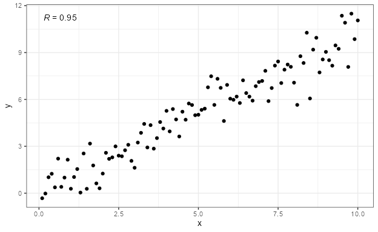

```r
ggplot(my.data, aes(x, y)) +
  geom_point() +
  stat_correlation()
```

The defaults support grouping by mapping of a factor to an aesthetic, in this example, `colour`.

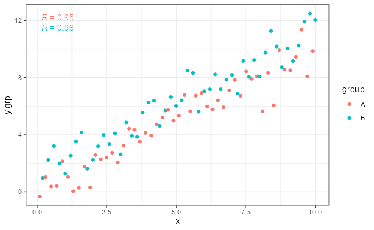

```r
ggplot(my.data, aes(x, y.grp, colour = group)) +
  geom_point() +
  stat_correlation()
```

Spearman’s ($\rho$, rho) and Kendall’s ($\tau$, tau) approaches to rank correlation are also supported, and can be selected with an argument passed to parameter `method`.

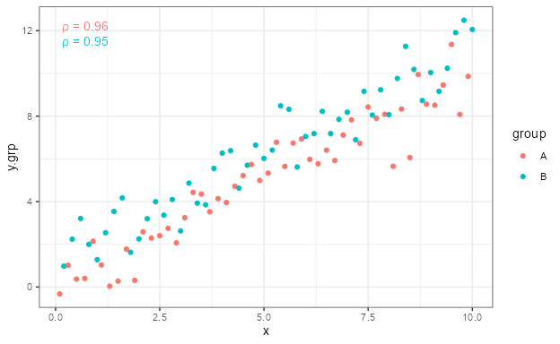

```r
ggplot(my.data, aes(x, y.grp, color = group)) +
  geom_point() +
  stat_correlation(method = "spearman")
```

Statistic `stat_correlation()` returns multiple formatted character strings that can be mapped to the `label` aesthetic. The returned character strings can be combined within a call to `aes()` using `after_stat()` together with functions such as `paste()` and mapped to the `label` aesthetic. However, using one of the wrapper functions `use_label()` or `f_use_label()` is simpler. The short “nicknames” with which the strings can be retrieved with these two functions are displayed in a message to the R console in interactive R sessions. For example:

```
'stat_correlation' labels (1 rows): P, n, grp, r, r.confint, method, cor, R2, t.
```

When data are grouped, one message is issued for each set of computed values or for each model fit. The names of the returned variables, with some exceptions, have the suffix `.label`, e.g., `n` corresponds to `n.label`. These longer names are also recognised by these two functions, and must always be used when retrieving them with `after_stat()`. In the message, `1 rows` indicates that the returned data frame has one row per group.

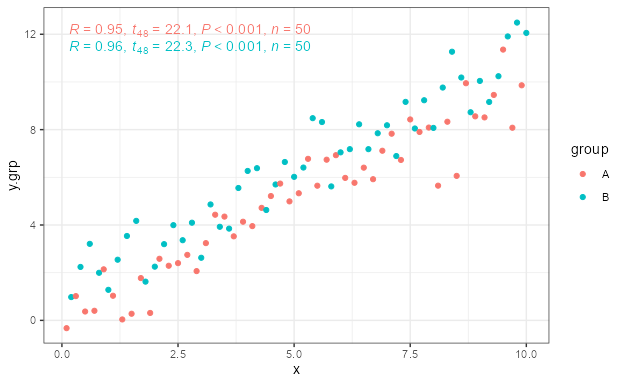

```r
ggplot(my.data, aes(x, y.grp, color = group)) +
  geom_point() +
  stat_correlation(mapping = use_label("r", "t", "P", "n"))
```

Together with the formatted `character` strings, `numeric`, and in special cases, also logical, values returned. When passing `output.type = "numeric"` in the call to the statistics, these are the only values returned. In this case the message lists them in interactive R sessions instead of the “label’s” nicknames.

```
'stat_correlation' variables (1 rows): t.value, df, p.value, cor, test, n, method, r.conf.level, r.confint.low, r.confint.high, npcx, npcy.
```

It is possible to set other aesthetics based on the outcome of the correlation test. Within `after_stat()` the full name of the variables is used. In this example, `cor` is the numeric value and `cor.label` the matching character string.

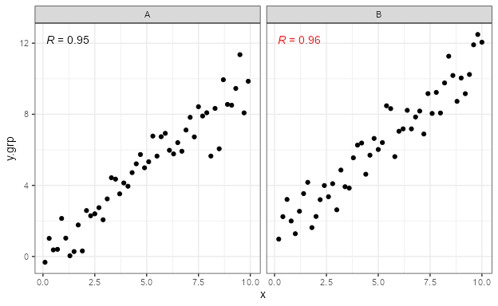

```r
ggplot(my.data, aes(x, y.grp)) +
  geom_point() +
  stat_correlation(mapping =
                     aes(label = after_stat(cor.label),
                         color =
                           after_stat(ifelse(cor > 0.955,
                                             "red", "black")))) +
  scale_color_identity() +
  facet_wrap(~group)
```

The approach shown above with `"red"` and `"black"` as colours, can be adapted to use `NA` (= invisible) as one colour to hide annotations automatically for individual groups of data based on the statistical outcomes.

In ‘ggplot2’ (>= 4.0.0) parameter `layout` controls deterministically on which panels plotting takes place. It is a parameter inherited by statistics and geometries from their parent object `layer` from ‘ggplot2’. For details, see the documentation of `ggplot2::layer()`.

Above the value of the correlation coefficient was used to set the colour of the annotation label. All other numeric values returned, such as `p.value` can be used similarly. Of course, any aesthetics recognized by the geometry such as `alpha` and `fontface` can be mapped to. As in ‘ggplot2’, any returned numeric variable can be also used with continuous scales if informative.

The statistics described below for adding equations of the fitted models and other fitted parameter estimates as annotations have user interfaces very similar to that of `stat_correaltion()`. To avoid repetition, the sections are not exhaustive, and focus on the most common use cases for each statistic. Most examples, with relatively small edits can be adapted to use other annotation statistics from ‘ggpmisc’.

## stat_poly_eq() and stat_poly_line()

A frequently used annotation in plots showing fitted lines is the display of the parameters estimates from the model fit as an equation. `stat_poly_eq()` automates this for models of *y* on *x* or *x* on *y* fitted with different model fit functions when the model `formula` is that of a regular polynomial, possibly lacking an intercept term. Even user-defined wrappers on model fitting functions can implement model selection or method selection. When the argument for `formula` is not a regular polynomial, the formatted character string for the model equation is set to `NA` but otherwise, all numeric values and all `character` labels for which estimates are available, are returned normally.

By default `stat_poly_line()` uses `method = "lm"` irrespective of the number of observations, while `stat_smooth()` from ‘ggplot2’ the method used by default depends on the number of observations. `stat_poly_line()` also adds features that provide additional flexibility in the control of the model prediction.

While `stat_poly_line()` displays the model prediction graphically like `stat_smooth()`, `stat_poly_eq()` is a “twin” that returns the parameter estimates and other statistics from the model fit both as formatted character strings ready to be added as annotations and as numeric values.

A frequently used annotation in plots showing fitted lines is the display of the parameters estimates from the model fit as an equation. `stat_poly_eq()` automates when the model `formula` is that of a regular polynomial, possibly lacking an intercept term. When the argument for `formula` is not a regular polynomial, this formatted character string is set to `NA`, but all numeric values and all `character` labels for which estimates are available, are returned normally. The formatted strings use different markup encodings depending on the geometry used: plotmath expressions, $\LaTeX$ for ‘xdvir’, markdown for ‘ggtext’, markdown for ‘marquee’ and plain ASCII text. Nevertheless, all examples below use R’s expression syntax.

The statistic `stat_poly_line()` has an user interface and default arguments matching those of `stat_poly_eq()`. It also supports natively a wide range of model fit functions including wrapper functions that do model selection and/or method selection based on data on a per group basis.

First, one example using defaults except for the model `formula`. The best practice, ensuring that the formula used in both *statistics* is the same is to assign the formula to a variable, as shown here. This is because the same model is fit twice to the same `data`, once in `stat_poly_line()` and once in `stat_poly_eq()`.

The terms in model formula for a polynomial can be entered individually or using R’s function `poly()`. When using function `poly()` it is necessary to set `raw = TRUE` as the default is to use orthogonal polynomials which although fitting the same line will have different estimates for the coefficients than those in the usual *raw* polynomials.

As above, messages are displayed in R interactive sessions, one by each of the two stats. Names of labels that are not available, i.e., set to `NA` are not listed.

```
'stat_poly_line' variables (80 rows): x, y, ymin, ymax, flipped_aes.
'stat_poly_eq' labels (1 rows): eq, R2, adj.R2, R2.confint, AIC, BIC, F, P, n, grp, method.
```

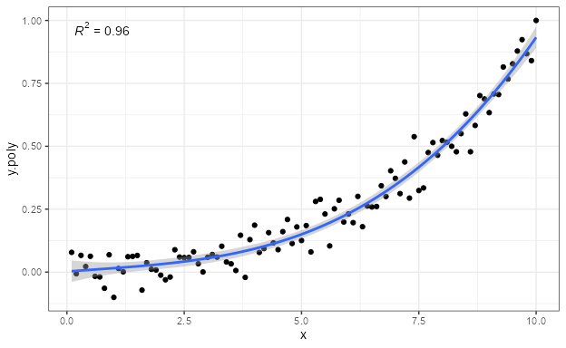

```r
formula <- y ~ poly(x, 3, raw = TRUE)
ggplot(my.data, aes(x, y.poly)) +
  geom_point() +
  stat_poly_line(formula = formula) +
  stat_poly_eq(formula = formula)
```

As indicated by the message, a ready formatted equation, `"eq"`, is returned as a *plotmath*-formatted `character` string ready to be parsed into an *expression*. Function `use_label()` or function `f_use_label()` can be used to select or assemble the expression and map it to the `label` aesthetic. The default separator used in `use_label()` is suitable for labels to be parsed into R expressions, but it can be over-ridden by passing an argument to parameter `sep`. In this example, the fitted model equation with `"eq"`, $R^2$ with `"R2"` and the number of observations in the group as `"n"`, are are mapped to the `label` aesthetic with `use_label()` .

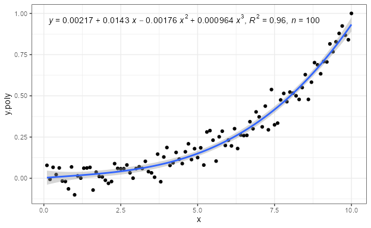

```r
formula <- y ~ poly(x, 3, raw = TRUE)
ggplot(my.data, aes(x, y.poly)) +
  geom_point() +
  stat_poly_line(formula = formula) +
  stat_poly_eq(mapping = use_label("eq", "R2", "n"), formula = formula)
```

In this case we add another layer with additional information, creating the mapping to the label aesthetic with function `f_use_label()`. The code below shows how the labels are inserted at the locations marked with `%s` in the format string. In this case, to keep the example simple, the labels are formatted as plain ASCII `"text"`.

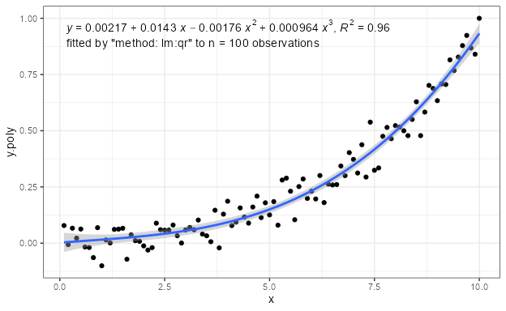

```r
formula <- y ~ poly(x, 3, raw = TRUE)
ggplot(my.data, aes(x, y.poly)) +
  geom_point() +
  stat_poly_line(formula = formula) +
  stat_poly_eq(mapping = use_label("eq", "R2"), formula = formula) +
  stat_poly_eq(mapping =
                 f_use_label("method", "n",
                             format =
                               "fitted by %s to %s observations"),
               output.type = "text",
               formula = formula,
               label.y = 0.88)
```

In the example above, two separate layers were needed because *plotmath* expressions do not support multiple lines of text. This is not the case with $\LaTeX$ and Markdown.

When different annotations are to be at far apart locations on the plotting area, it is always necessary to add them as separate plot layers. Below, the adjusted coefficient of determination, $R^2_\mathrm{adj}$, and Akaike’s information criterion, AIC, are inserted in different sizes and in opposite corners using two plot layers, i.e., We call `stat_poly_eq()` twice.

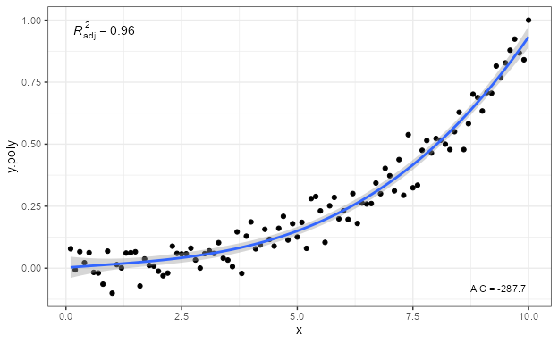

```r
formula <- y ~ poly(x, 3, raw = TRUE)
ggplot(my.data, aes(x, y.poly)) +
  geom_point() +
  stat_poly_line(formula = formula) +
  stat_poly_eq(mapping = use_label("adj.R2"), formula = formula) +
  stat_poly_eq(mapping = use_label("AIC"), label.x = "right", label.y = "bottom", size = 3,
               formula = formula)
```

As shown for `stat_correlation()`, the mapping can also be done with `ggplot2::aes()` using the full bare name of the variable returned using `ggplot2::after_stat()`. This is useful when `use_label()` and `f_use_label()` are not flexible enough, such as when mappings are complex or use computed `numeric` or `logical` values in addition or instead of the ready formatted character strings.

To be able to fully exploit the flexibility of `f_use_label()` or when constructing the character string within a call to `aes()`, familiarity with the markup encoding used is needed. For example, inserting a comma plus white space in a *plotmath* expression requires some trickery in the argument passed to parameter `sep` when `paste()`, or `use_label()` are used. Do also note the need to *escape* the embedded quotation marks as `\"`. Combining the labels in this way ensures correct alignment. To insert only white space `sep = "~~~~~"` can be used, with each tilde character, `~`, adding a rather small amount of horizontal white space. Expressions support in-line font face changes with `plain()`, `italic()`, `bold()` or `bolditalic()` an other commands as described in the help entry for `plotmath.`

It can be easier in many cases to insert a literal character string into an expression, as shown nelow, by enclosing the string in `*`. *Plotmath* expressions can be used in ‘ggplot2’ also for the scale `name`, including axis titles, as shown below, to ensure consistency with the typesetting.

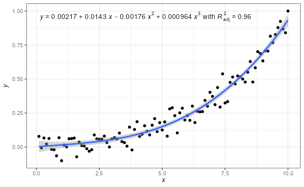

```r
formula <- y ~ poly(x, 3, raw = TRUE)
ggplot(my.data, aes(x, y.poly)) +
  geom_point() +
  stat_poly_line(formula = formula) +
  stat_poly_eq(mapping = use_label("eq", "adj.R2", sep = "*\" with \"*"),
               formula = formula) +
  labs(x = expression(italic(x)), y = expression(italic(y)))
```

`stat_poly_eq()` allows some control on the generation of the formatted fitted model equation and other formatted character labels. (For details, please, consult the documentation of each function.) For example the number of significant digits displayed, whether to use upper- or lower case $P$ for probabilities, displaying polynomials with increasing or decreasing powers, as well as the substitution of *x* and *y* by more meaninful symbols. A few examples follow.

Next, one example of how to remove the left hand side (*lhs*).

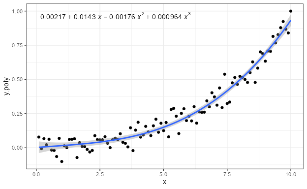

```r
formula <- y ~ poly(x, 3, raw = TRUE)
ggplot(my.data, aes(x, y.poly)) +
  geom_point() +
  stat_poly_line(formula = formula) +
  stat_poly_eq(mapping = use_label("eq"),
               eq.with.lhs = FALSE,
               formula = formula)
```

Replacing the default *lhs* $y$ by $\hat{y}$.

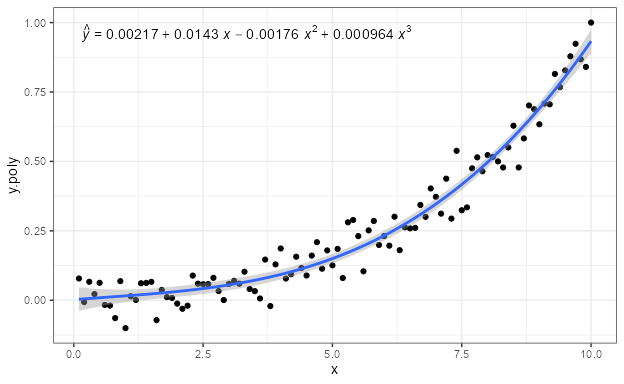

```r
formula <- y ~ poly(x, 3, raw = TRUE)
ggplot(my.data, aes(x, y.poly)) +
  geom_point() +
  stat_poly_line(formula = formula) +
  stat_poly_eq(mapping = use_label("eq"),
               eq.with.lhs = "italic(hat(y))~`=`~",
               formula = formula)
```

Replacing both the *lhs*, $y$, and the variable symbol, $x$, used on the *rhs*.

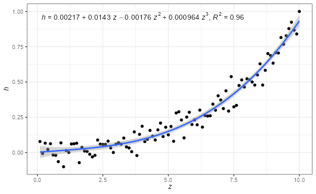

```r
formula <- y ~ poly(x, 3, raw = TRUE)
ggplot(my.data, aes(x, y.poly)) +
  geom_point() +
  stat_poly_line(formula = formula) +
  stat_poly_eq(mapping = use_label("eq", "R2"),
               eq.with.lhs = "italic(h)~`=`~",
               eq.x.rhs = "~italic(z)",
               formula = formula) +
  labs(x = expression(italic(z)), y = expression(italic(h)))
```

As any valid *plotmath* expression can be used, Greek letters are also supported, as well as the inclusion in the label of variable transformations used in the model formula or applied to the data. In addition, in the next example we insert white space in between the parameter estimates and the variable symbol in the equation.

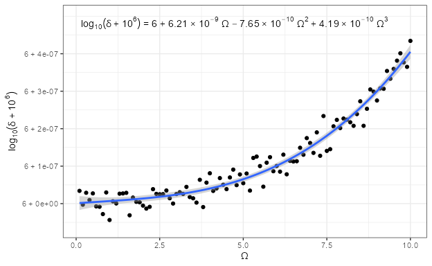

```r
formula <- y ~ poly(x, 3, raw = TRUE)
ggplot(my.data, aes(x, log10(y.poly + 1e6))) +
  geom_point() +
  stat_poly_line(formula = formula) +
  stat_poly_eq(mapping = use_label("eq"),
               eq.with.lhs = "plain(log)[10](italic(delta)+10^6)~`=`~",
               eq.x.rhs = "~Omega",
               formula = formula) +
  labs(y = expression(plain(log)[10](italic(delta)+10^6)),
       x = expression(Omega)) +
  scale_y_continuous(expand = expansion(c(0.1, 0.2)),
                     labels = function(x) {sprintf("6 + %.0e", x - 6)})
```

A degree 1 polynomial is linear regression with `formula = y ~ x`, which is the default. Linear regression through the origin is supported by passing `formula = y ~ x - 1`, or `formula = y ~ x + 0`. High order polynomials are most easily encoded using `poly()` in the model formula, as shown above with `formula = y ~ poly(x, 3, raw = TRUE)`.

Intercept forced to zero for a third degree polynomial defined explicitly, as this case is not supported by `poly()`.

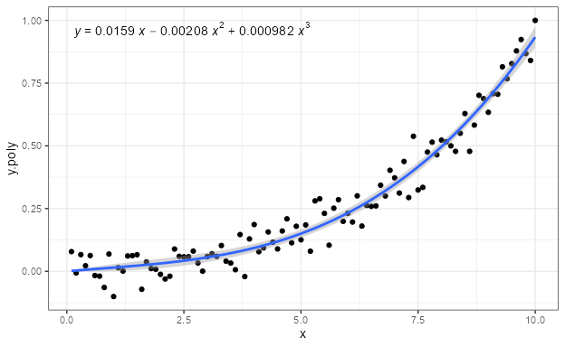

```r
formula <- y ~ x + I(x^2) + I(x^3) - 1
ggplot(my.data, aes(x, y.poly)) +
  geom_point() +
  stat_poly_line(formula = formula) +
  stat_poly_eq(aes(label = after_stat(eq.label)), formula = formula)
```

Even when labels are returned, numeric values are also returned. This can be used in `ggplot2::aes()` for example to show the equation only if a certain condition like a minimum value for `r.square` or maximum value for `p.value` has been exceeded. This is useful when the same model fitting code and plot are used with different data. This is the case when a report with embedded code is run repeatedly on different data, but also when the data in different groupings or planels in a single plot differ.

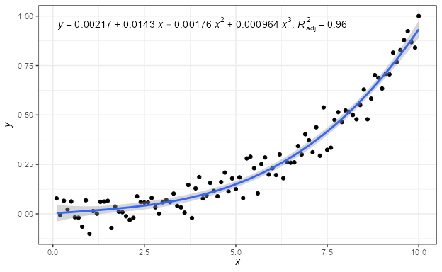

```r
formula <- y ~ poly(x, 3, raw = TRUE)
ggplot(my.data, aes(x, y.poly)) +
  geom_point() +
  stat_poly_line(formula = formula) +
  stat_poly_eq(aes(label =
                     after_stat(
                       ifelse(adj.r.squared > 0.3,
                                   paste(eq.label, adj.rr.label,
                                         sep = "*\", \"*"),
                                   adj.rr.label))),
               formula = formula) +
  labs(x = expression(italic(x)), y = expression(italic(y)))
```

We give below several examples to demonstrate how other components of the `ggplot` object affect the behaviour of this statistic.

*Facets work as expected both with fixed or free scales.* Although below we have to adjust the size of the font used for the equation.

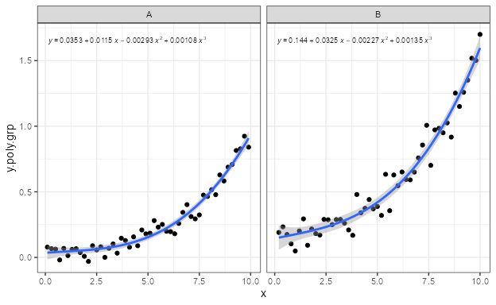

```r
formula <- y ~ poly(x, 3, raw = TRUE)
ggplot(my.data, aes(x, y.poly.grp)) +
  geom_point() +
  stat_poly_line(formula = formula) +
  stat_poly_eq(aes(label = after_stat(eq.label)), size = 2.5,
               formula = formula) +
  facet_wrap(~group)
```

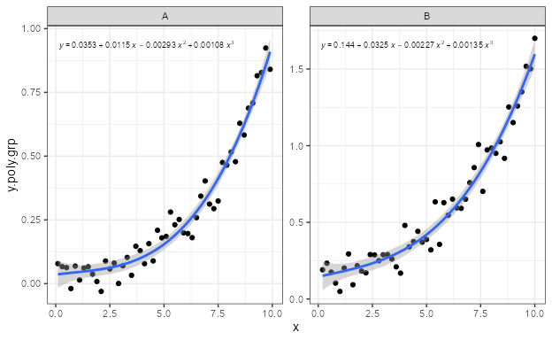

```r
formula <- y ~ poly(x, 3, raw = TRUE)
ggplot(my.data, aes(x, y.poly.grp)) +
  geom_point() +
  stat_poly_line(formula = formula) +
  stat_poly_eq(aes(label = after_stat(eq.label)),
               size = 2.5,
               formula = formula) +
  facet_wrap(~group, scales = "free_y")
```

*Grouping works as expected.* In this example we create groups using the colour aesthetic, but factors or discrete variables mapped to other aesthetics including the “invisible” `group` aesthetic are handled in the same way.

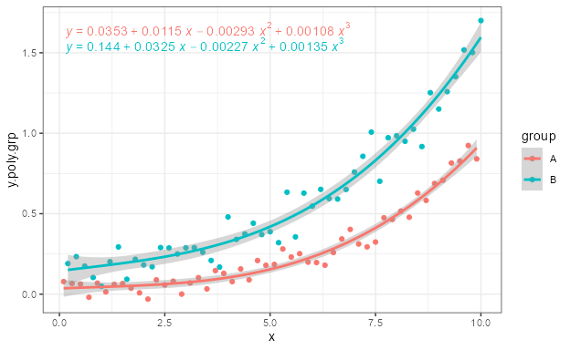

```r
formula <- y ~ poly(x, 3, raw = TRUE)
ggplot(my.data,
       aes(x, y.poly.grp, colour = group)) +
  geom_point() +
  stat_poly_line(formula = formula) +
  stat_poly_eq(aes(label = after_stat(eq.label)),
               formula = formula)
```

When not using colours, a label can be added to the equation to identify the group, using a pseudo-aesthetic named `grp.label`.

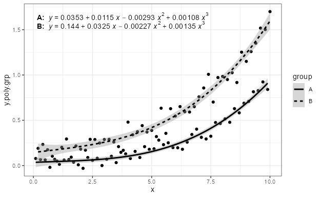

```r
formula <- y ~ poly(x, 3, raw = TRUE)
ggplot(my.data,
       aes(x, y.poly.grp,
           linetype = group,
           grp.label = group)) +
  geom_point() +
  stat_poly_line(formula = formula, colour = "black") +
  stat_poly_eq(aes(label =
                     after_stat(paste("bold(", grp.label, "*\":\")~~",
                                      eq.label, sep = ""))),
               formula = formula)
```

`stat_poly_eq()` computes the positions of labels for the different groups to avoid overlaps. Flexibility in this automation is provided by parameters, `vstep` and `hstep` giving the distance between succesive labels, and `label.x` and `label.y` giving the starting position, when of length equal to one, all in values ranging between 0 and 1, when using the default `ggpp::geom_text_npc()`. `label.x` and `label.y` in addition accept character strings, similarly as for justification in ‘ggplot2’ geoms.

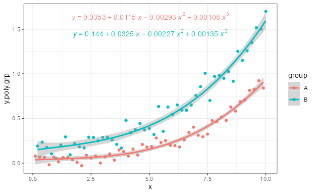

```r
formula <- y ~ poly(x, 3, raw = TRUE)
ggplot(my.data,
       aes(x, y.poly.grp, colour = group)) +
  geom_point() +
  stat_poly_line(formula = formula) +
  stat_poly_eq(aes(label = after_stat(eq.label)),
               formula = formula,
               label.x = "centre",
               vstep = 0.1)
```

The arguments passed to `label.x` and `label.y` can directly given the positions of each of the labels.

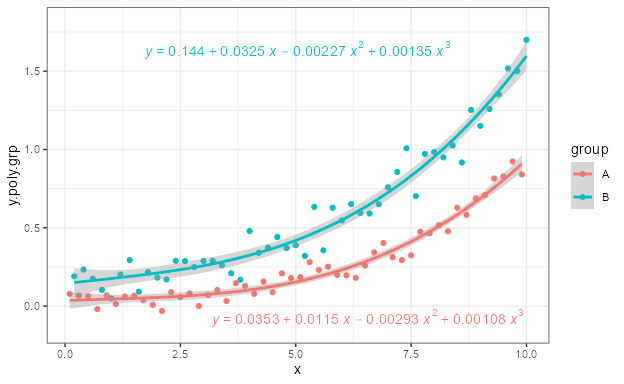

```r
formula <- y ~ poly(x, 3, raw = TRUE)
ggplot(my.data,
       aes(x, y.poly.grp, colour = group)) +
  geom_point() +
  stat_poly_line(formula = formula) +
  stat_poly_eq(aes(label = after_stat(eq.label)),
               formula = formula,
               label.x = c("right", "centre"),
               label.y = c("bottom", "top")) +
  scale_y_continuous(expand = expansion(c(0.12, 0.12)))
```

If grouping is not the same within each panel created by faceting, i.e., not all groups have data in all panels, the automatic location of labels results in gaps for the factor levels not present in a given panel as in this example. This behaviour ensures consistent positioning of labels for the same groups across panels. If positioning that leaves no gaps is desired, it is possible to explicitly pass the positions for each individual label as shown above.

In some cases gaps may be desirable to highlight the missing groups, but when not, the positions can be set manually as in the next example.

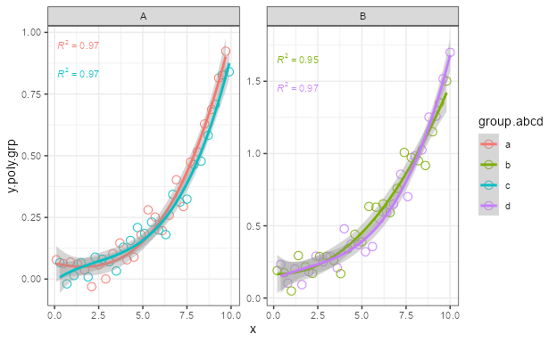

```r
formula <- y ~ poly(x, 3, raw = TRUE)
ggplot(my.data,
       aes(x, y.poly.grp, colour = group.abcd)) +
  geom_point(shape = 21, size = 3) +
  stat_poly_line(formula = formula) +
  stat_poly_eq(aes(label = after_stat(rr.label)),
               size = 3,
               formula = formula) +
  facet_wrap(~group, scales = "free_y")
```

When setting positions manually with arguments (in `npc` units, 0..1) passed as argument to `label.y` (and/or to `label.x`), be aware that the positions must be given in the order of the levels of the groups, e,g,, factor levels in the case of grouping based on a single aesthetic. This is not necessarily the plot panel order!

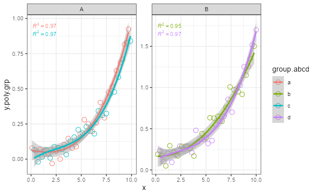

```r
formula <- y ~ poly(x, 3, raw = TRUE)
ggplot(my.data,
       aes(x, y.poly.grp, colour = group.abcd)) +
  geom_point(shape = 21, size = 3) +
  stat_poly_line(formula = formula) +
  stat_poly_eq(use_label("R2"),
               size = 3,
               label.y = c(0.95, 0.95, 0.9, 0.9),
               formula = formula) +
  facet_wrap(~group, scales = "free_y")
```

It is possible to use `ggplot2::geom_text()`, `ggplot2::geom_label()`, `ggtext::geom_richtext()`, `marquee::geom_marquee()`, `dvixr::geom_latex()`, `ggrepel::geom_text_repel()`, `ggrepel::geom_label_repel()`, `ggrepel::geom_marquee_repel()`, etc., instead of the default `ggpp::geom_text_npc()` (or `ggpp::geom_label_npc()`) but in such case, if label coordinates are given as numeric values they should be expressed in native data coordinates.

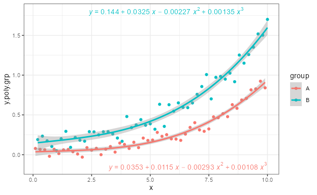

```r
formula <- y ~ poly(x, 3, raw = TRUE)
ggplot(my.data,
       aes(x, y.poly.grp, colour = group)) +
  geom_point() +
  stat_poly_line(formula = formula) +
  stat_poly_eq(geom = "text",
               aes(label = after_stat(eq.label)),
               label.x = c(10, 9),
               label.y = c(-0.15, 1.8),
               hjust = "inward",
               formula = formula)
```

**Note:** Automatic positioning using `ggplot2::geom_text()` and `ggplot2::geom_label()` is supported except when faceting uses free scales. In this case `ggpp::geom_text_npc()` and/or `ggpp::geom_label_npc()` or positions supplied by the user must be used.

Occasionally, possibly as a demonstration in teaching, we may want to compare a fit of *x* on *y* and one of *y* on *x* in the same plot. The example below also serves as introduction to the next section, which describes the use of *major axis regression* or *Model II* regression.

As is the case for model fitting functions themselves, which variable is dependent (response) and which is independent (explanatory) is simply indicated by the model equation passed as argument to `formula`, or consistently with `ggplot2::stat_smooth()` through parameter `orientation` as show below.

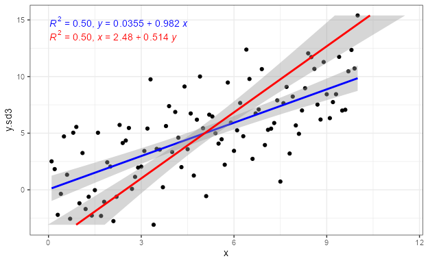

```r
ggplot(my.data, aes(x, y.sd3)) +
  geom_point() +
  stat_poly_line(color = "blue") +
  stat_poly_eq(mapping = use_label("R2", "eq"), color = "blue") +
  stat_poly_line(color = "red", orientation = "y") +
  stat_poly_eq(mapping = use_label("R2", "eq"), color = "red",
               orientation = "y", label.y = 0.89)
```

Examples of the use of `stat_poly_line()` and `stat_poly_eq()` with other model fitting functions and formulas are available as articles at [the ‘ggpmisc’ web site](https://docs.r4photobiology.info/ggpmisc/).

## stat_ma_eq() and stat_ma_line()

Package ‘lmodel2’ implements Model II fits for major axis (MA), standard major axis (SMA) and ranged major axis (RMA) regression for linear relationships. These approaches of regression are used when both variables are subject to random variation and the intention is not to estimate *y* from *x* but instead to describe the slope of the relationship between them. A typical example in biology are allometric relationships. Rather frequently, OLS linear model fits are used in cases where Model II regression would be preferable. **MA and SMA models can be also fit with `stat_poly_line()` and `stat_poly_eq()` using functions from package ‘smatr’.

In the figure above we see that the ordinary least squares (OLS) linear regression of *y* on *x* and *x* on *y* differ. Major axis regression provides an estimate of the slope that is independent of the direction of the relationship relation. $R^2$ remains the same in all cases, and with major axis regression while the coefficient estimates in the equation depend on the `orientation`, they correspond to exactly the same line.

The message issued at the R console in an interactive R session is:

```
'stat_ma_eq' labels (1 rows): eq, R2, P, theta, n, grp, method.
```

As described above for `stat_correlation()` and `stat_poly_eq()`, the message informs about available short names for labels that can be mapped to the `label` aesthetic with `use_label()` or `f_use_label()`.

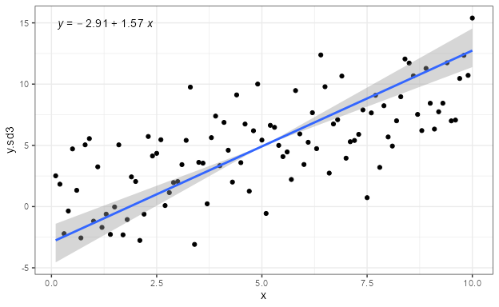

```r
ggplot(my.data, aes(x, y.sd3)) +
  geom_point() +
  stat_ma_line() +
  stat_ma_eq(mapping = use_label("eq"))
```

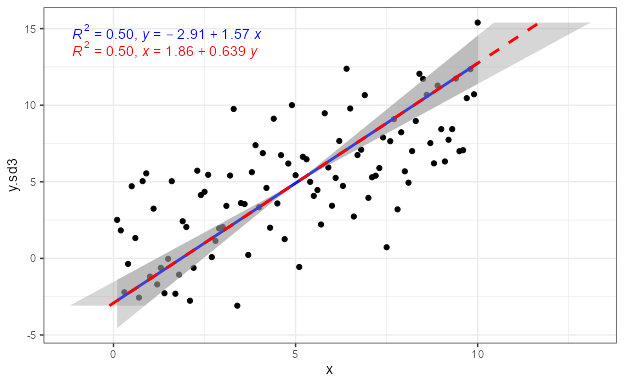

```r
ggplot(my.data, aes(x, y.sd3)) +
  geom_point() +
  stat_ma_line(color = "blue") +
  stat_ma_eq(mapping = use_label("R2", "eq"),
             color = "blue") +
  stat_ma_line(color = "red",
               orientation = "y",
               linetype = "dashed") +
  stat_ma_eq(mapping = use_label("R2", "eq"),
             color = "red",
             orientation = "y",
             label.y = 0.9)
```

MA and SMA are models describing strictly linear relationships. Orthogonal least squares can be used to fit polynomials, and other models and is supported by `stat_poly_line()` and `stat_poly_eq().

Additional examples of the use of `stat_ma_line()` and `stat_ma_equation()` and alternatives are available in articles at [the ‘ggpmisc’ web site](https://docs.r4photobiology.info/ggpmisc/).